# Explore_bikeshare_data

### Explore Bike Share Data

For this project, your goal is to ask and answer three questions about the available bikeshare data from Washington, Chicago, and New York. This notebook can be submitted directly through the workspace when you are confident in your results.

You will be graded against the project [Rubric](https://review.udacity.com/#!/rubrics/2508/view) by a mentor after you have submitted. To get you started, you can use the template below, but feel free to be creative in your solutions!

```r
#load libraries
library(tidyverse)
library(ggplot2)
library(readr)
library(lubridate)

new_york_city = read.csv('new_york_city.csv')
washington = read.csv('washington.csv')
chicago = read.csv('chicago.csv')
```

```r
#create combined data without the extra columns in chicago and NY city, create diferentiatior column "City"

new_york_city_8col <- new_york_city %>%
  select(-c(8,
            9)) %>%
  cbind(City="New York")

chicago_8col <- chicago %>%
  select(-c(8,
            9)) %>%
  cbind(City="Chicago")

washington_8col <- washington %>%
  cbind(City="Washington")

all_cities <- rbind(new_york_city_8col,
                    chicago_8col,
                    washington_8col)

names(all_cities)[1]="ID"
names(all_cities)[2]="Start_Time"
names(all_cities)[3]="End_Time"
names(all_cities)[4]="Trip_Duration"
names(all_cities)[5]="Start_Station"
names(all_cities)[6]="End_Station"
names(all_cities)[7]="User_Type"
```

```r
head(new_york_city_8col)
```

| X | Start.Time | End.Time | Trip.Duration | Start.Station | End.Station | User.Type | City |
| --- | --- | --- | --- | --- | --- | --- | --- |
| 5688089 | 2017-06-11 14:55:05 | 2017-06-11 15:08:21 | 795 | Suffolk St & Stanton St | W Broadway & Spring St | Subscriber | New York |
| 4096714 | 2017-05-11 15:30:11 | 2017-05-11 15:41:43 | 692 | Lexington Ave & E 63 St | 1 Ave & E 78 St | Subscriber | New York |
| 2173887 | 2017-03-29 13:26:26 | 2017-03-29 13:48:31 | 1325 | 1 Pl & Clinton St | Henry St & Degraw St | Subscriber | New York |
| 3945638 | 2017-05-08 19:47:18 | 2017-05-08 19:59:01 | 703 | Barrow St & Hudson St | W 20 St & 8 Ave | Subscriber | New York |
| 6208972 | 2017-06-21 07:49:16 | 2017-06-21 07:54:46 | 329 | 1 Ave & E 44 St | E 53 St & 3 Ave | Subscriber | New York |
| 1285652 | 2017-02-22 18:55:24 | 2017-02-22 19:12:03 | 998 | State St & Smith St | Bond St & Fulton St | Subscriber | New York |

```r
head(chicago_8col)
```

| X | Start.Time | End.Time | Trip.Duration | Start.Station | End.Station | User.Type | City |
| --- | --- | --- | --- | --- | --- | --- | --- |
| 1423854 | 2017-06-23 15:09:32 | 2017-06-23 15:14:53 | 321 | Wood St & Hubbard St | Damen Ave & Chicago Ave | Subscriber | Chicago |
| 955915 | 2017-05-25 18:19:03 | 2017-05-25 18:45:53 | 1610 | Theater on the Lake | Sheffield Ave & Waveland Ave | Subscriber | Chicago |
| 9031 | 2017-01-04 08:27:49 | 2017-01-04 08:34:45 | 416 | May St & Taylor St | Wood St & Taylor St | Subscriber | Chicago |
| 304487 | 2017-03-06 13:49:38 | 2017-03-06 13:55:28 | 350 | Christiana Ave & Lawrence Ave | St. Louis Ave & Balmoral Ave | Subscriber | Chicago |
| 45207 | 2017-01-17 14:53:07 | 2017-01-17 15:02:01 | 534 | Clark St & Randolph St | Desplaines St & Jackson Blvd | Subscriber | Chicago |
| 1473887 | 2017-06-26 09:01:20 | 2017-06-26 09:11:06 | 586 | Clinton St & Washington Blvd | Canal St & Taylor St | Subscriber | Chicago |

### Question 1

**What is the most common month?**

```r
#To Generate "Date" type column and assign name to Month

Month <- all_cities %>%
  mutate(Clean.Start.Date = as.Date(Start_Time),
         Clean.End.Time = as.Date(End_Time)) %>%
  mutate(Month = month(Clean.Start.Date)) %>%
  mutate(Month = case_when(Month == "1" ~ "January",
                         Month == "2" ~ "February",
                         Month == "3" ~ "March",
                         Month == "4" ~ "April",
                         Month == "5" ~ "May",
                         Month == "6" ~ "June"))


#To change column Month to be a factor

Month$Month <- factor(Month$Month, levels=month.name)
```

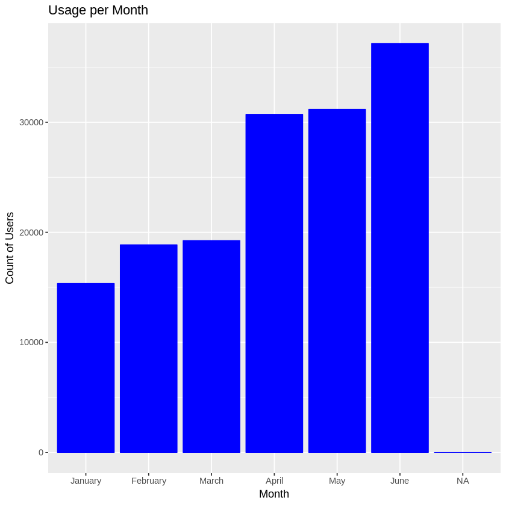

```r
#Graph
ggplot(data=Month, aes(x=Month)) +
  geom_bar(color="blue", fill="blue")+
  scale_x_discrete() +
  ylab('Count of Users') +
  ggtitle("Usage per Month")
```

```r
#Summary Data
table(Month$Month)
```

[output not shown]

**The month with the highest recurrence is June.**

To obtain this result the first task was to take the Start Time & End Time and transform tell R that this is a date using the as.Date function, once it is converted to "Date" time we can do transformations, I used the library(lubridate) that gives us functions that separate dates depending on the analysis we want to do (by day, month, year, etc.). I separated per month to answer our question, the output will be the number of the month. Using the function mutate() + case_when() we can create "tags", for each month (number), to transform each row on the data.frame to its corresponding month. Once we have our "Month" column created with each month's full name, we need to change the column into a factor so later on ggplot2 we can use the function scale_x_discrete() and it'll recognize it to be ordered in calendar sequence instead of alphabetically. Since we're dealing with recurrences, a simple bar chart would be able to give us this information. Since our categorical data is Months, I assigned the x-axis to this variable "Month", and the count() function that will be used to create the plot by the package will be the aggregating the rows by this category, giving us the "Count of Users"

### Question 2

**What is the most common start station?**

```r
#Summary Data

Start_Stations <- all_cities %>%
  group_by(Start_Station) %>%
  summarise(Incidences=n()) %>%
  top_n(3) %>%
  arrange(desc(Incidences))
```

```r
Start_Stations
```

[output not shown]

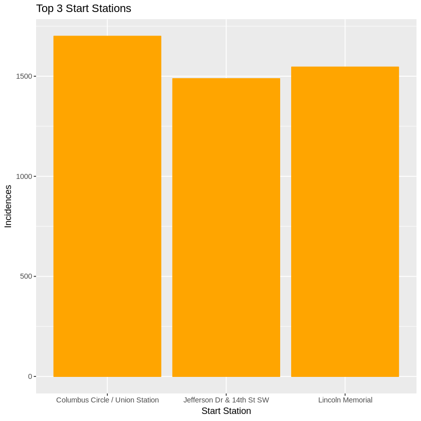

```r
#Graph
all_cities %>%
  group_by(Start_Station) %>%
  summarise(Incidences=n()) %>%
  top_n(3) %>%
  ggplot(., aes(x=Start_Station, y=Incidences))+
  geom_bar(stat="Identity", color="orange", fill="orange") +
  xlab('Start Station') +
  ylab('Incidences') +
  ggtitle("Top 3 Start Stations")
```

**The start station with the highest incidence is Columbus Circle/Union Station.**

To be able to tell which was the start station that had the highest incidence, a bit of data wrangling to prepare our data is required. I performed a grouping per Start_Station to aggregate by unique station names, the summarise() + n() functions in conjunction give us a countdown of the individual rows that were aggregated and give that column a name, which I named "Incidences", if we left the data as is and create a graph out of this dataset we'd get graph that is impossible to read due to the ammount of Stations in the analysis. To avoid this I also added the top_n() function to give me top 3 Stations. Since the output will be correct but untidy, I used the arrange() +desc() functions to get an ordered result.

To build the graph I took the same logic I used to create our summary data explained previously, this is a way of subsetting our data frames to get the countdowns and aggregations needed and graph without having to create separate data tables. In reality, it wasn't necessary to create the Start_Stations data.frame, but it is useful to be able to reassure we're getting the correct calculations. The x-axis is the categorical data that will define the countdown that will be made by the plot (Incidences).

### Question 3

**What is the most common end station?**

```r
#Summary Data
End_Stations <-all_cities %>%
  group_by(End_Station) %>%
  summarise(Incidences=n()) %>%
  top_n(3) %>%
  arrange(desc(Incidences))
```

```r
End_Stations
```

| End_Station | Incidences |
| --- | --- |
| Columbus Circle / Union Station | 1767 |
| Jefferson Dr & 14th St SW | 1603 |
| Lincoln Memorial | 1514 |

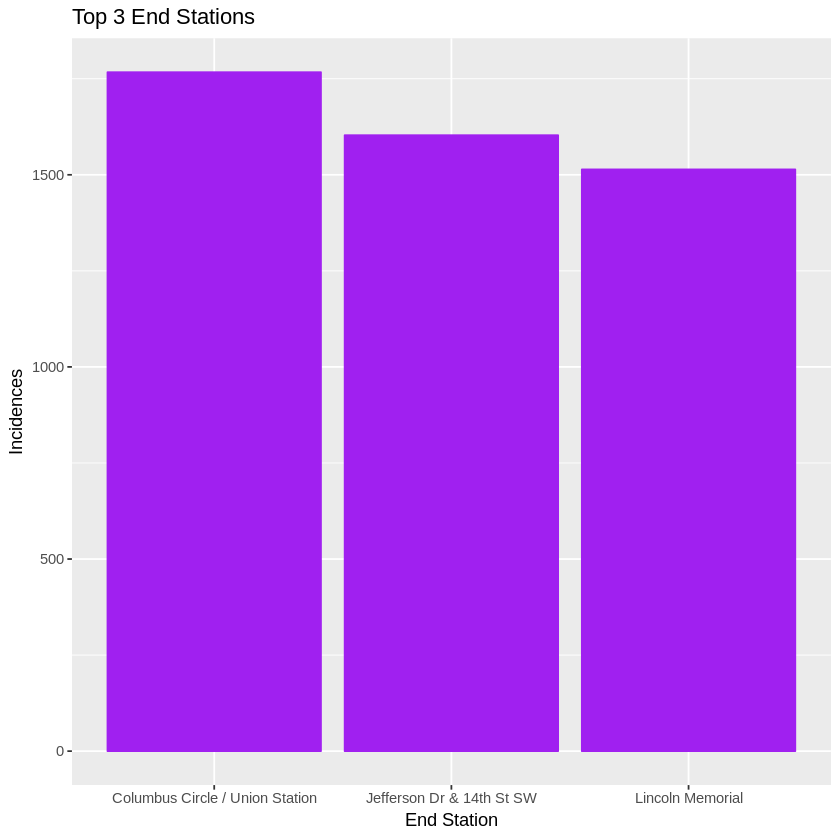

```r
#Graph
all_cities %>%
  group_by(End_Station) %>%
  summarise(Incidences=n()) %>%
  top_n(3) %>%
  ggplot(., aes(x=End_Station, y=Incidences))+
  geom_bar(stat="Identity", color="purple", fill="purple") +
  xlab('End Station') +
  ylab('Incidences') +
  ggtitle("Top 3 End Stations")
```

**The Columbus Circle/Union Station is the End Station with the highest Incidence.**

The logic and calculations were similar to the analysis made for the Start Station that was explained above.

**End Remarks:**

Columbus Circle/Union Station is the start and end station with the highest recurrence of people using the bike share system. What I can infer is that this station could have a strategic geographical location, which would explain the high affluence of people. The month with the highest usage of shared bikes is June. The data sample that was used stops at June; however, it would be interesting to see the 12 month, full data set. At a simple glance I can assume the weather in June will be directly related to the affluence of people, therefore winter months will have a much lower count number of bike shares.

## Finishing Up

> Congratulations! You have reached the end of the Explore Bikeshare Data Project. You should be very proud of all you have accomplished!

> **Tip**: Once you are satisfied with your work here, check over your report to make sure that it is satisfies all the areas of the [rubric](https://review.udacity.com/#!/rubrics/2508/view).

## Directions to Submit

> Before you submit your project, you need to create a .html or .pdf version of this notebook in the workspace here. To do that, run the code cell below. If it worked correctly, you should get a return code of 0, and you should see the generated .html file in the workspace directory (click on the orange Jupyter icon in the upper left).

> Alternatively, you can download this report as .html via the **File** > **Download as** submenu, and then manually upload it into the workspace directory by clicking on the orange Jupyter icon in the upper left, then using the Upload button.

> Once you've done this, you can submit your project by clicking on the "Submit Project" button in the lower right here. This will create and submit a zip file with this .ipynb doc and the .html or .pdf version you created. Congratulations!

```r
system('python -m nbconvert Explore_bikeshare_data.ipynb')
```